# Mood Disorder & Suicidality Outcome Variable EDA

Sam A. Sievertsen

2025-01-25

# Exploratory Data Analysis (EDA) of variables to be used as outcome metrics related to mood disorders and suicidality in the ABCD dataset

The most up to date list of variables to used as outcomes in the current study, including their role, domain, details of each variable as it relates to the ABCD dataset, etc., can be found here.

The following report contains information regarding the:

1. Integrity of the data
2. Assessment of outliers in the data
3. Skewness + appropriateness of the mean as the measure of central tendency for continuous variables
4. Shape of each variables’ distribution

## 1. Integrity of the Data

## 1. Define the N, percent, and range of outcome variables of interest at the 4Y assessment timepoint

| Variable | N Non-Missing | Percent Non-Missing | Range/Unique Values | Missing Scores > 1 |
| --- | --- | --- | --- | --- |
| bipolar_I_dx | 4754 | 100.00 | 0, 1 | NA |
| bipolar_II_dx | 4754 | 100.00 | 0, 1 | NA |
| any_bipolar_dx | 4754 | 100.00 | 0, 1 | NA |
| suicidal_thinking | 4754 | 100.00 | 0, 1 | NA |
| suicide_attempt | 4754 | 100.00 | 0, 1 | NA |
| nssi | 4754 | 100.00 | 0, 1 | NA |
| cbcl_scr_dsm5_depress_t | 4677 | 98.38 | 50, 96 | 0 |
| cbcl_scr_dsm5_anxdisord_t | 4677 | 98.38 | 50, 94 | 0 |
| cbcl_scr_syn_attention_t | 4677 | 98.38 | 50, 90 | 0 |
| cbcl_scr_syn_aggressive_t | 4677 | 98.38 | 50, 87 | 0 |

## 2. Visually and Quantitatively Assess for any Outliers in the Data

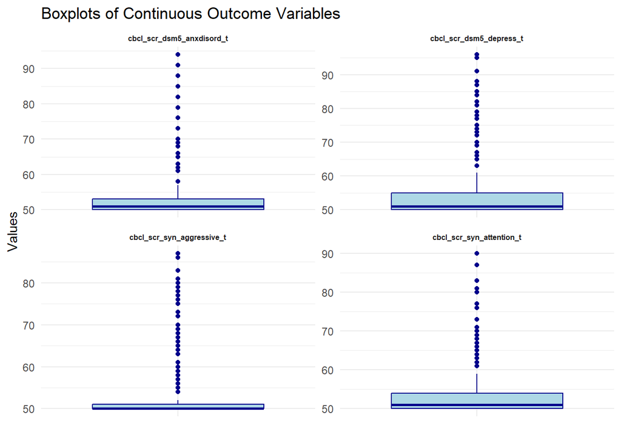

Based on the boxplots of the continuous (secondary) outcome variables, it does not appear as though any values are out of range or otherwise unexpected/impactful outliers.

## 3. Appropriateness of the Mean as a Measure of Central Tendency

While clustering methods used in this study do not require parametric assumptions, the secondary continuous outcome measures - `cbcl_scr_dsm5_depress_t`, `cbcl_scr_dsm5_anxdisord_t`, `cbcl_scr_syn_attention_t`, and `cbcl_scr_syn_aggressive_t` - will serve as dependent variables in statistical models that do. Therefore, examining their skewness is essential to assess their symmetry and appropriateness for said analyses.

Below, skewness values for the four secondary outcome measures are presented.

Skewness Values for Secondary Continuous Outcome Measures

| Variable | Skewness |
| --- | --- |
| cbcl_scr_dsm5_depress_t | 1.95 |
| cbcl_scr_dsm5_anxdisord_t | 2.49 |
| cbcl_scr_syn_attention_t | 2.28 |
| cbcl_scr_syn_aggressive_t | 3.30 |

Evidenced by the table above, the CBCL aggression problems scale score (`cbcl_scr_syn_aggressive_t`) may exhibit problematic skew (i.e., > 3). When assessing results of the linear mixed effects models, this will need to be taken into account, and applicability of transformation of variable (e.g., through box-cox or log transform) should be evaluated.

## 4. Shape of Each Variables’ Distribution

The shape of the distribution for each continuous variable and frequency distribution of each categorical variable is outlined below, both in terms of summary statistics derived from and a graphical histogram with density overlay of relevant data:

| Variable | Type | Mean | Median | SD | Min | Max | Levels | Frequencies |
| --- | --- | --- | --- | --- | --- | --- | --- | --- |
| cbcl_scr_dsm5_depress_t | Continuous | 53.988454 | 51 | 6.3894725 | 50 | 96 | NA | NA |
| cbcl_scr_dsm5_anxdisord_t | Continuous | 53.480436 | 51 | 5.9426519 | 50 | 94 | NA | NA |
| cbcl_scr_syn_attention_t | Continuous | 53.297413 | 51 | 5.3847537 | 50 | 90 | NA | NA |
| cbcl_scr_syn_aggressive_t | Continuous | 51.879838 | 50 | 4.2902716 | 50 | 87 | NA | NA |
| bipolar_I_dx | Categorical | NA | NA | NA | NA | NA | 0, 1 | 4692, 62 |
| bipolar_II_dx | Categorical | NA | NA | NA | NA | NA | 0, 1 | 4728, 26 |
| any_bipolar_dx | Categorical | NA | NA | NA | NA | NA | 0, 1 | 4624, 130 |
| suicidal_thinking | Categorical | NA | NA | NA | NA | NA | 0, 1 | 3911, 843 |
| suicide_attempt | Categorical | NA | NA | NA | NA | NA | 0, 1 | 4564, 190 |
| nssi | Categorical | NA | NA | NA | NA | NA | 0, 1 | 4162, 592 |

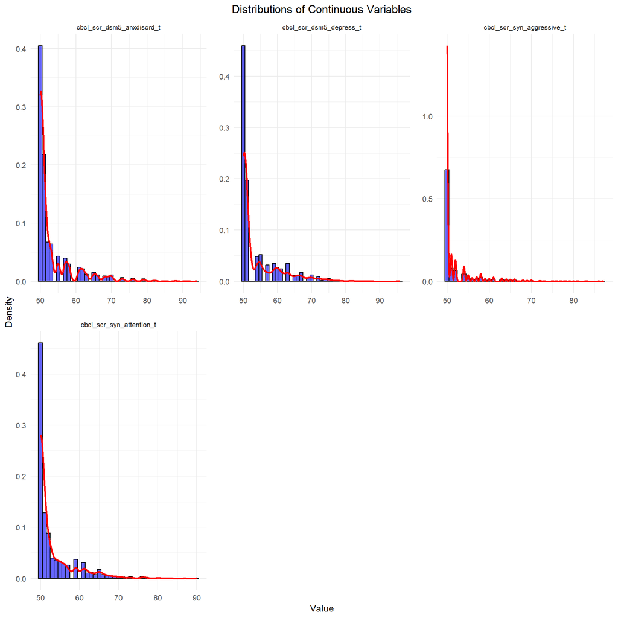

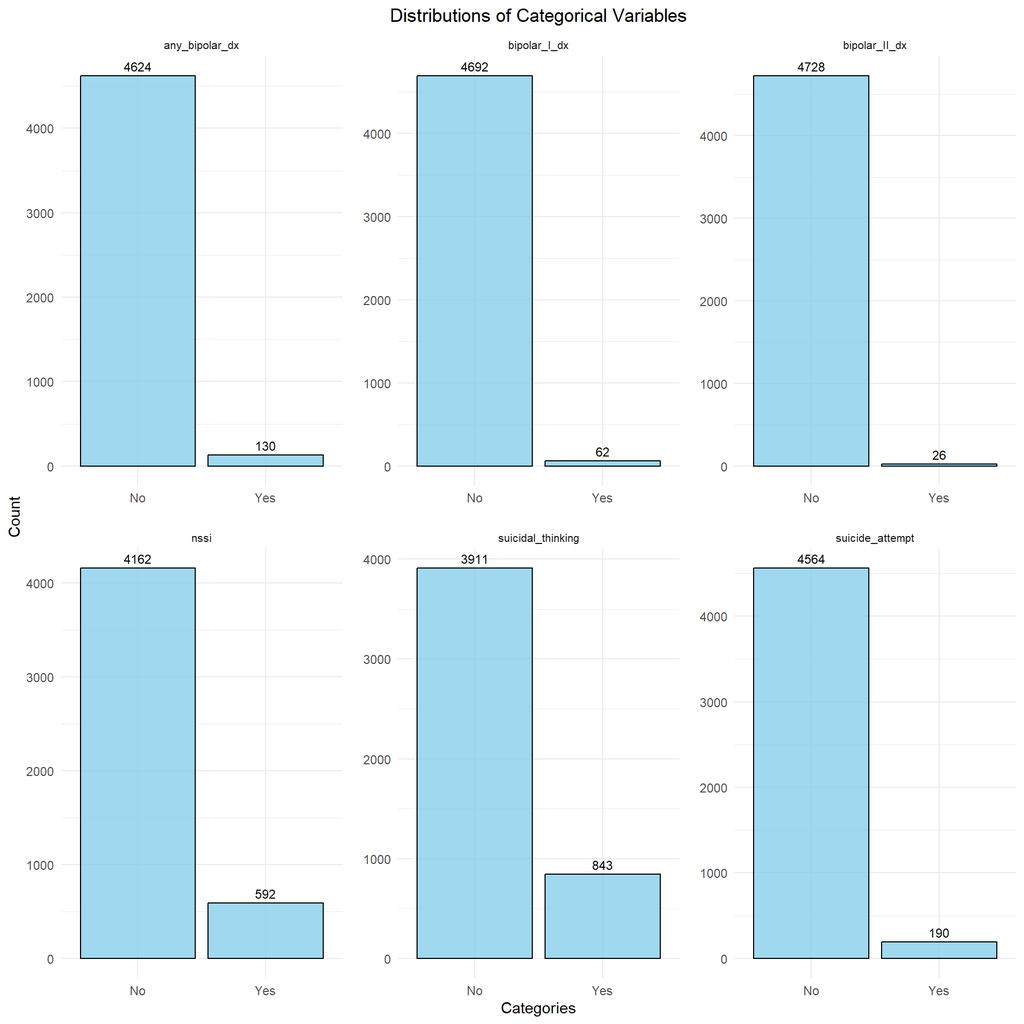

Distributions of continuous variables and rates of categorical variables are shown above. While continuous variables exhibit noticeable skew, and the CBCL aggression problem scale results will need to be interpreted with caution/re-evaluated during modeling, no other problematic distributions are not noted herein.